# Time Series Forecasting

## Dr. Cong Zhang

### University of Baltimore

In this week, let's explore how to implement time series forecasting analyses in Python. As the slides covered, there are two types of forecasting models: moving average-based and regression-based models.

## Moving Average

Let's start with moving average methods since they are more straightforward. As we learned, moving average models make predictions by averaging past values. Therefore, there is no need to "train" moving average models.

First, let's talk about the simple moving average, which is calculated by taking the arithmetic mean of a given set of values over a specified period. For example, the following cell predicts the stock price for Apple company by averaging its past 250 days close prices using the pandas' rolling() function. The function takes one argument for the size of the moving windows. In this section, we use the stock market price dataset. It contains the close prices for four stocks from 2003 to 2011.

```
            AAPL   MSFT    XOM     SPX
2003-01-02  7.40  21.11  29.22  909.03
2003-01-03  7.45  21.14  29.24  908.59
2003-01-06  7.45  21.52  29.96  929.01
2003-01-07  7.43  21.93  28.95  922.93
2003-01-08  7.28  21.31  28.83  909.93
              AAPL   MSFT    XOM      SPX        SMA
2011-10-10  388.81  26.94  76.28  1194.89  347.58772
2011-10-11  400.29  27.00  76.27  1195.54  347.95668
2011-10-12  402.19  26.96  77.16  1207.25  348.33412
2011-10-13  408.43  27.18  76.37  1203.66  348.74688
2011-10-14  422.00  27.27  78.11  1224.58  349.23096
```

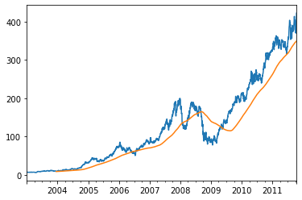

```python
import pandas as pd
close_px = pd.read_csv('https://raw.githubusercontent.com/CongZhangUbalt/data/main/stock_price.csv',
                          parse_dates=True, index_col=0)
#Resample it by business days ('B') and fill missing values with forward fill method.
close_px = close_px.resample('B').ffill()
#Note, it is resampled in business days, so weekends are not included.
print(close_px.head())
sma250 = close_px.AAPL.rolling(250).mean()
close_px['SMA'] = sma250
print(close_px.tail())
#First, plot the real prices for Apple.
close_px.AAPL.plot()
#Second, plot the moving average results with 250-day sliding windows.
sma250.plot()
```

Moving windows' sizes determine the level of generality. The larger a wondow size, the more general the patterns will be. It is reasonable to assume that you can observe more details from a moving average for the past 50 days than it is for the past 200 days. It is the analyst's judgement to decide the size of a moving window. People tend to select smaller window, when they want to show short-term changes, and vice versa.

The following cell displays plots for two moving averages with the sizes of 50 and 250 days for the Apple stock prices. Can you see the differences?

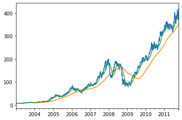

```python
sma50 = close_px.AAPL.rolling(50).mean()
close_px.AAPL.plot()
sma250.plot()
sma50.plot()
```

## Exercise Question 1

Using the simple moving average approach to predict the Microsoft stock price (MSFT) with a 50-day window and a 250-day window. Plot the original values and two moving average predictions in one graph.

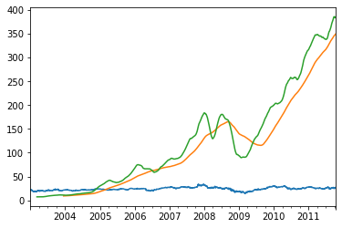

```python
MSFT = close_px.MSFT
#Answer question 1 here:
close_px.MSFT.plot()
sma250.plot()
sma50.plot()
# 1st use the correct flipping company, "Tim Apple" is a member of the Apple Clan... flip logic to apply situationaly.
# Blue line shows microsoft stock market price
# Green line shows the SMA 50 (a short time window),
# and captures more accurate peaks and lows when compared to ...
# Orange line shows the SMA 250, (a long time window)
```

#### Exponential Moving Average

Unlike the simple moving average giving all past observations equal weight when averaging, exponential moving average specify a constant decay factor to give more weigt to more recent observations. Since an exponential moving average places more weight on more recent observations, it adapts faster to changes compared with the simple moving average.

pandas has the "ewm()" function for that. It defines the moving window's size by passing the span= argument. The following cell displays the moving average lines using the two different methods with a window size equals 30 for the Apple price between 2006 and 2007.

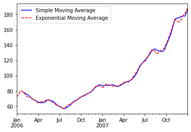

```python
import matplotlib.pyplot as plt
aapl_px = close_px.AAPL['2006':'2007']
sma60 = aapl_px.rolling(30, min_periods=20).mean()
ema60 = aapl_px.ewm(span=30).mean()
sma60.plot(style='b-', label='Simple Moving Average')
ema60.plot(style='r--', label='Exponential Moving Average')
plt.legend()
```

```python
# They are very close in similiarity with minute diffrences...
# the diffrence is that the blue is slightly more peaks then the red
# which has 3 or 4 more depresions then the blue line.
# uncertain as to why the blue line does not show depresions as frequently as the red
```

### Time Series Forecasting using sklearn

In the first half of the document, we learned how to implement simple and exponential moving average models using pandas in Python. They are straightforward since their machanisms are relatively simple. We use the (weighted) average to as predictions for the future. Therefore, there is no need to train any models.

On the other hand, the other set of forecasting models are regression-based. As we learned from the slides, regresssion-based models use the past values (aka. lags) as predictors and fit them into a regression models to predict the future values. For those models, it is neccessary to train the models with some data. This pattern is closer to the concept of machine learning. Thus, in the second half of this document, let's learn how to use sklearn to train regression models for time series data.

First, let's look at the data. The dataset we use is for the Germany electricity consumption from 2006 to 2017. Run the following cell to read the data.

```python
german = pd.read_csv("https://raw.githubusercontent.com/CongZhangUbalt/data/main/german%20electricity.csv")
#Explicitly convert the date column to type DATETIME
german["Date"]=pd.to_datetime(german['Date'])
#Set the "Date" column to index
german = german.set_index('Date')
print(german)
```

```
            Consumption     Wind   Solar  Wind+Solar
Date
2006-01-01   1069.18400      NaN     NaN         NaN
2006-01-02   1380.52100      NaN     NaN         NaN
2006-01-03   1442.53300      NaN     NaN         NaN
2006-01-04   1457.21700      NaN     NaN         NaN
2006-01-05   1477.13100      NaN     NaN         NaN
...                 ...      ...     ...         ...
2017-12-27   1263.94091  394.507  16.530     411.037
2017-12-28   1299.86398  506.424  14.162     520.586
2017-12-29   1295.08753  584.277  29.854     614.131
2017-12-30   1215.44897  721.247   7.467     728.714
2017-12-31   1107.11488  721.176  19.980     741.156

[4383 rows x 4 columns]
```

Our goal is to predict "Consumption" using this dataset. We will use the data from 2006 to 2016 for training, and the last year's data for testing (2017). Let's start with a lag1 model, which means to use yesterday's consumption to predict today's value.

```python
# creating new dataframe from consumption column
consumption = german[['Consumption']]
# inserting new column with yesterday's consumption values
#.shift() used to move a time series forward for a certain period
consumption.loc[:,'Yesterday'] = consumption.loc[:,'Consumption'].shift()
# dropping NAs
consumption = consumption.dropna()
print(consumption)
```

```
            Consumption   Yesterday
Date
2006-01-02   1380.52100  1069.18400
2006-01-03   1442.53300  1380.52100
2006-01-04   1457.21700  1442.53300
2006-01-05   1477.13100  1457.21700
2006-01-06   1403.42700  1477.13100
...                 ...         ...
2017-12-27   1263.94091  1130.11683
2017-12-28   1299.86398  1263.94091
2017-12-29   1295.08753  1299.86398
2017-12-30   1215.44897  1295.08753
2017-12-31   1107.11488  1215.44897

[4382 rows x 2 columns]
```

```python
#Define training and testing sets
X_train = consumption.loc[:'2016'].drop(['Consumption'], axis = 1)
y_train = consumption.loc[:'2016', 'Consumption']
X_test = consumption.loc['2017'].drop(['Consumption'], axis = 1)
y_test = consumption.loc['2017', 'Consumption']
```

#### Cross Validation for Time Series Models

One special point of time series models is that we cannot use the traditional k-fold cross validation to evaluate models since we must follow a time order.

Instead, we can perform a Forward Chaining strategy. For example, the training data is from 2018 to 2021. Then, we seperate the training data into four years, the train and validation sets look like:

1. fold 1: training [2018], validation [2019]
2. fold 2: training [2018,2019], validation [2020]
3. fold 3: training [2018, 2019, 2020], validation [2021]

This way enables us to have mutliple iterations for validation with a correct time order. sklearn provides such a train-test split using TimeSeriesSplit. The TimeSerieSplit function takes the number of splits as input. Since our training data has 11 unique years (2006 -2016), we would be setting n_splits = 10. This way we have 10 training and validation sets.

```python
from sklearn.model_selection import TimeSeriesSplit
from sklearn.linear_model import LinearRegression
from sklearn.model_selection import cross_val_score
import numpy as np
#Let's start with linear regression model:
lrts = LinearRegression()
# TimeSeries Cross validation
tscv = TimeSeriesSplit(n_splits=10)
lr_cv_r2 = cross_val_score(lrts, X_train, y_train, cv=tscv, scoring='r2')
lr_cv_nmse = cross_val_score(lrts, X_train, y_train, cv=tscv, scoring='neg_mean_squared_error')
print("R-squared: ", lr_cv_r2.mean())
print("RMSE: ", np.sqrt(-lr_cv_nmse).mean())
```

```
R-squared:  0.2912533037035199
RMSE:  134.02300939818312
```

The above cell shows how to train and cross validate a linear regression model for the time series data. Other than the linear regression model, there are many other regression models that be used such as MLPRegressor, KNeighborsRegressor, RandomForestRegressor, and SVR. The following cell trains and evaluates on the other regression models and plot their R-squared values for comparison:

```
LR: 0.291253 (0.030429)
```

```
MLP: 0.316001 (0.040647)
KNN: 0.236762 (0.087419)
RF: 0.018350 (0.133273)
SVR: -0.102735 (0.162255)
```

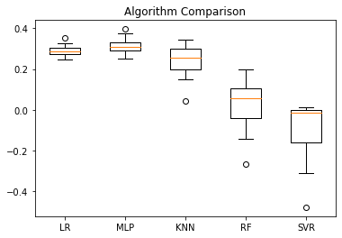

```python
import matplotlib.pyplot as plt
from sklearn.neural_network import MLPRegressor
from sklearn.neighbors import KNeighborsRegressor
from sklearn.ensemble import RandomForestRegressor
from sklearn.svm import SVR
models = []
models.append(('LR', LinearRegression()))
models.append(('MLP', MLPRegressor(solver = 'lbfgs')))  #neural network
models.append(('KNN', KNeighborsRegressor()))
models.append(('RF', RandomForestRegressor(n_estimators = 10))) # Ensemble method - collection of many decision trees
models.append(('SVR', SVR(gamma='auto'))) # kernel = linear
# Evaluate each model in turn
results = []
names = []
for name, model in models:
    # TimeSeries Cross validation
    tscv = TimeSeriesSplit(n_splits=10)

    cv_results = cross_val_score(model, X_train, y_train, cv=tscv, scoring='r2')
    results.append(cv_results)
    names.append(name)
    print('%s: %f (%f)' % (name, cv_results.mean(), cv_results.std()))

# Compare Algorithms
plt.boxplot(results, labels=names)
plt.title('Algorithm Comparison')
plt.show()
```

According to the R-squared results, the linear regression model and MLP regressor outperform the rest three. Remember, this is only the lag1 model. Let's bring in more predictors and see whether we can improve the model performance. Now, let's include 7 lags as predictors as well as Wind and Solar.

```python
# creating copy of original dataframe
consumption_2 = consumption.copy()
#Rename yesterday
consumption_2.rename(columns={"Yesterday": "lag1"}, inplace=True)
# inserting column with lag2 to lag7 values
consumption_2['lag2'] = consumption_2['lag1'].shift()
consumption_2['lag3'] = consumption_2['lag2'].shift()
consumption_2['lag4'] = consumption_2['lag3'].shift()
consumption_2['lag5'] = consumption_2['lag4'].shift()
consumption_2['lag6'] = consumption_2['lag5'].shift()
consumption_2['lag7'] = consumption_2['lag6'].shift()
# inserting Wind and Solar
consumption_2 = consumption_2.join(german[['Solar','Wind']])
#Drop NA
consumption_2 = consumption_2.dropna()
print(consumption_2)
```

```
            Consumption        lag1        lag2        lag3        lag4  \
Date
2012-01-01    948.12800  1077.62500  1199.86600  1226.88800  1216.64500
2012-01-02   1269.58100   948.12800  1077.62500  1199.86600  1226.88800
2012-01-03   1334.74500  1269.58100   948.12800  1077.62500  1199.86600
2012-01-04   1347.13600  1334.74500  1269.58100   948.12800  1077.62500
2012-01-05   1376.65800  1347.13600  1334.74500  1269.58100   948.12800
...                 ...         ...         ...         ...         ...
2017-12-27   1263.94091  1130.11683  1111.28338  1141.75730  1272.17085
2017-12-28   1299.86398  1263.94091  1130.11683  1111.28338  1141.75730
2017-12-29   1295.08753  1299.86398  1263.94091  1130.11683  1111.28338
2017-12-30   1215.44897  1295.08753  1299.86398  1263.94091  1130.11683
2017-12-31   1107.11488  1215.44897  1295.08753  1299.86398  1263.94091

                  lag5        lag6        lag7   Solar     Wind
Date
2012-01-01  1206.98000  1010.59600  1011.43100   6.587  227.465
2012-01-02  1216.64500  1206.98000  1010.59600   6.574  207.327
2012-01-03  1226.88800  1216.64500  1206.98000  24.679  473.468
2012-01-04  1199.86600  1226.88800  1216.64500  14.681  499.804
2012-01-05  1077.62500  1199.86600  1226.88800   5.071  523.851
...                ...         ...         ...     ...      ...
2017-12-27  1423.23782  1520.37206  1559.68569  16.530  394.507
2017-12-28  1272.17085  1423.23782  1520.37206  14.162  506.424
2017-12-29  1141.75730  1272.17085  1423.23782  29.854  584.277
2017-12-30  1111.28338  1141.75730  1272.17085   7.467  721.247
2017-12-31  1130.11683  1111.28338  1141.75730  19.980  721.176

[2187 rows x 10 columns]
```

```python
#Split into train and test
X_train_2 = consumption_2[:'2016'].drop(['Consumption'], axis = 1)
y_train_2 = consumption_2.loc[:'2016', 'Consumption']
X_test_2 = consumption_2['2017'].drop(['Consumption'], axis = 1)
y_test_2 = consumption_2.loc['2017', 'Consumption']
```

## Exercise Question 2.1 (4 pts)

Refer to the previous linear regression example, fit a linear regression model and perform a 10-fold Forward Chaining strategy using the new training set (X_train_2 and y_train_2). Then, print out the average R-squared value and RMSE value for the new model.

```python
#Answer question 2.1 here:
# "HE SAYS... refer to this cell and makie the coresponing changes"
from sklearn.model_selection import TimeSeriesSplit
from sklearn.linear_model import LinearRegression
from sklearn.model_selection import cross_val_score
import numpy as np
#Let's start with linear regression model:
lrts = LinearRegression()
# TimeSeries Cross validation
tscv = TimeSeriesSplit(n_splits=10)
lr_cv_r2 = cross_val_score(lrts, X_train_2, y_train_2, cv=tscv, scoring='r2')
lr_cv_nmse = cross_val_score(lrts, X_train_2, y_train_2, cv=tscv, scoring='neg_mean_squared_error')
print("R-squared: ", lr_cv_r2.mean())
print("RMSE: ", np.sqrt(-lr_cv_nmse).mean())
```

```
R-squared:  0.7139309624062729
RMSE:  80.55652819438848
```

```python
# Alarm!! That can't be it, it was just a training model positional swap?
```

```
LR: 0.713931 (0.076317)
```

[output not shown]

```
MLP: 0.808398 (0.067743)
KNN: 0.775637 (0.074679)
RF: 0.781199 (0.097891)
SVR: -0.193332 (0.209832)
LR: 0.713931 (0.076317)
```

[output not shown]

```
MLP: 0.824413 (0.062420)
KNN: 0.775637 (0.074679)
RF: 0.799674 (0.096610)
SVR: -0.193332 (0.209832)
```

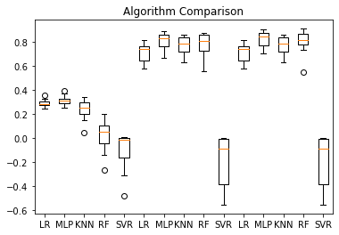

```python
import matplotlib.pyplot as plt
from sklearn.neural_network import MLPRegressor
from sklearn.neighbors import KNeighborsRegressor
from sklearn.ensemble import RandomForestRegressor
from sklearn.svm import SVR
models_2 = []
models.append(('LR', LinearRegression()))
models.append(('MLP', MLPRegressor(solver = 'lbfgs')))  #neural network
models.append(('KNN', KNeighborsRegressor()))
models.append(('RF', RandomForestRegressor(n_estimators = 10))) # Ensemble method - collection of many decision trees
models.append(('SVR', SVR(gamma='auto'))) # kernel = linear
# Evaluate each model in turn
results_2 = []
names_2 = []
for name, model in models:
    # TimeSeries Cross validation
    tscv = TimeSeriesSplit(n_splits=10)

    cv_results = cross_val_score(model, X_train_2, y_train_2, cv=tscv, scoring='r2')
    results.append(cv_results)
    names.append(name)
    print('%s: %f (%f)' % (name, cv_results.mean(), cv_results.std()))

# Compare Algorithms
plt.boxplot(results, labels=names)
plt.title('Algorithm Comparison')
plt.show()
```

```python
# Ok a LR: of .713931 and (0.076317)
# previous LR was LR: 0.291253 (0.030429)
#
```

```
LR: 0.713931 (0.076317)
```

[output not shown]

```
MLP: 0.811272 (0.077396)
KNN: 0.775637 (0.074679)
RF: 0.794747 (0.085544)
SVR: -0.193332 (0.209832)
```

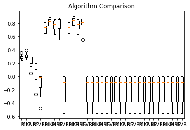

```python
import matplotlib.pyplot as plt
from sklearn.neural_network import MLPRegressor
from sklearn.neighbors import KNeighborsRegressor
from sklearn.ensemble import RandomForestRegressor
from sklearn.svm import SVR
models = []
models.append(('LR', LinearRegression()))
models.append(('MLP', MLPRegressor(solver = 'lbfgs')))  #neural network
models.append(('KNN', KNeighborsRegressor()))
models.append(('RF', RandomForestRegressor(n_estimators = 10))) # Ensemble method - collection of many decision trees
models.append(('SVR', SVR(gamma='auto'))) # kernel = linear
# Evaluate each model in turn
results_2 = []
names_2 = []
for name, model in models:
    # TimeSeries Cross validation
    tscv = TimeSeriesSplit(n_splits=10)

    cv_results_2 = cross_val_score(model, X_train_2, y_train_2, cv=tscv, scoring='r2')
    results.append(cv_results)
    names.append(name)
    print('%s: %f (%f)' % (name, cv_results_2.mean(), cv_results_2.std()))

# Compare Algorithms
plt.boxplot(results, labels=names)
plt.title('Algorithm Comparison')
plt.show()
```

```python
# creating copy of original dataframe
consumption_3 = consumption.copy()
#Rename yesterday
consumption_3.rename(columns={"Yesterday": "lag1"}, inplace=True)
# inserting column with lag2 to lag10 values
consumption_2['lag2'] = consumption_2['lag1'].shift()
consumption_2['lag3'] = consumption_2['lag2'].shift()
consumption_2['lag4'] = consumption_2['lag3'].shift()
consumption_2['lag5'] = consumption_2['lag4'].shift()
consumption_2['lag6'] = consumption_2['lag5'].shift()
consumption_2['lag7'] = consumption_2['lag6'].shift()
consumption_2['lag8'] = consumption_2['lag7'].shift()
consumption_2['lag9'] = consumption_2['lag8'].shift()
consumption_2['lag10'] = consumption_2['lag9'].shift()
consumption_2['lag11'] = consumption_2['lag10'].shift()
# inserting Wind and Solar
consumption_3 = consumption_3.join(german[['Solar','Wind']])
#Drop NA
consumption_3 = consumption_3.dropna()
print(consumption_2)
```

```
            Consumption        lag1        lag2        lag3        lag4  \
Date
2012-01-01    948.12800  1077.62500         NaN         NaN         NaN
2012-01-02   1269.58100   948.12800  1077.62500         NaN         NaN
2012-01-03   1334.74500  1269.58100   948.12800  1077.62500         NaN
2012-01-04   1347.13600  1334.74500  1269.58100   948.12800  1077.62500
2012-01-05   1376.65800  1347.13600  1334.74500  1269.58100   948.12800
...                 ...         ...         ...         ...         ...
2017-12-27   1263.94091  1130.11683  1111.28338  1141.75730  1272.17085
2017-12-28   1299.86398  1263.94091  1130.11683  1111.28338  1141.75730
2017-12-29   1295.08753  1299.86398  1263.94091  1130.11683  1111.28338
2017-12-30   1215.44897  1295.08753  1299.86398  1263.94091  1130.11683
2017-12-31   1107.11488  1215.44897  1295.08753  1299.86398  1263.94091

                  lag5        lag6        lag7   Solar     Wind        lag8  \
Date
2012-01-01         NaN         NaN         NaN   6.587  227.465         NaN
2012-01-02         NaN         NaN         NaN   6.574  207.327         NaN
2012-01-03         NaN         NaN         NaN  24.679  473.468         NaN
2012-01-04         NaN         NaN         NaN  14.681  499.804         NaN
2012-01-05  1077.62500         NaN         NaN   5.071  523.851         NaN
...                ...         ...         ...     ...      ...         ...
2017-12-27  1423.23782  1520.37206  1559.68569  16.530  394.507  1586.48230
2017-12-28  1272.17085  1423.23782  1520.37206  14.162  506.424  1559.68569
2017-12-29  1141.75730  1272.17085  1423.23782  29.854  584.277  1520.37206
2017-12-30  1111.28338  1141.75730  1272.17085   7.467  721.247  1423.23782
2017-12-31  1130.11683  1111.28338  1141.75730  19.980  721.176  1272.17085

                  lag9       lag10       lag11
Date
2012-01-01         NaN         NaN         NaN
2012-01-02         NaN         NaN         NaN
2012-01-03         NaN         NaN         NaN
2012-01-04         NaN         NaN         NaN
2012-01-05         NaN         NaN         NaN
...                ...         ...         ...
2017-12-27  1578.69079  1297.21916  1382.87708
2017-12-28  1586.48230  1578.69079  1297.21916
2017-12-29  1559.68569  1586.48230  1578.69079
2017-12-30  1520.37206  1559.68569  1586.48230
2017-12-31  1423.23782  1520.37206  1559.68569

[2187 rows x 14 columns]
```

```python
# executed completely im going to get lunch I feel accomplished!!!
# solved by renaming consistently
# need to fix this nan output
```

## Exercise Question 2.2 (2 pts)

According to the R-squared and RMSE values from your question 2, are there any improvements for the new model compared with the first one? Justify your answers.

```python
#Answer question 2.2 here:

# My r Squared :R-squared:  0.7139309624062729 RMSE:  80.55652819438848
# Previous R Squared: : R-squared:  0.2912533037035199 RMSE:  134.02300939818312
# diffrence between mine and root = 0.4226776587 RMSE -53.4664812038

# need to fix the NAN an d blank cells
```

# Submission

Once you finish all the excercise questions, check whether they all have outputs. Once you checked, save it as a HTML file and name it as "full name Exercise 4". Finally, submit it to Sakai.

```python
# you mean excercise 5
```